# Why household outcomes are higher in villages dominated by backward casts in the poor rural Indian region of Uttar Pradesh and Bihar ?

Emmanuel LANDAU

2024-12-26

This final project mainly relies on the study [Caste as an Impediment to Trade](https://www.aeaweb.org/articles?id=10.1257/app.3.1.239) by Siwan Anderson, published in January 2011 in the American Economic Journal: Applied Economics. This study explores the economic implications of the Indian caste system, which places individuals in a social hierarchy based on birth.As such, the focus of our project will be to determine why household outcomes are higher in villages dominated by backward castes than in villages dominated by upper castes in the poor rural Indian regions of Uttar Pradesh and Bihar. Backward Caste Dominated Villages are defined as those where the dominant caste group is a Lower Backward Agricultural Caste (BAC). Despite the presence of other caste groups such as Upper Castes, Other Backward Castes (OBC), and Scheduled Castes (SC), these villages are primarily characterized by the dominance of BACs economically, and in terms of land ownership. By contrast, Upper Caste Dominated Villages are those where the Upper Castes hold the majority of the land and consequently, the economic power, even though backward castes also live in these villages. The dataset used consists of Hindu villages where approximately 48% are dominated by the upper caste, and 42% by a lower backward agricultural caste (BAC). The data was gathered through the Uttar Pradesh and Bihar LSMS Survey (1997/98) that covered 120 villages randomly selected throughout 12 districts in Uttar Pradesh and 13 districts in Bihar, at a total of 2,250 households. These villages are predominantly rural, in which their economies are reliant on agriculture. In line with the methodology of the paper, we will attempt to demonstrate that the variation in which caste dominates a village is exogenous, with respect to current economic outcomes (to show that the prevailing economic conditions in these villages today are not influencing the question of which caste is dominant). Then, we will demonstrate that household incomes are higher in low caste dominated villages. Finally we will explore why ground water access discrepancies (based on castes) ultimately explain income differences across the two types of villages. We will use the OLS, 2SLS, and probit models described in the sections to conduct our analysis.

# Section I: Establishing Exogeneity

Firstly, the paper informs us that during the colonial era, land rights were concentrated amongst high-caste citizens. After a post-colonial reform in 1950, significant portions of land ownership rights were transferred to low-caste citizens. The paper discusses how in the states of Uttar Pradesh and Bihar, two dominant caste groups (upper castes and BACs) are evenly dispersed, with historical data displaying a significant presence of villages without upper caste members. Additionally, Siwan Anderson argues that there is no proof of significant caste-based migration which could have influenced the composition of these villages. By highlighting these points, the researcher ensures that we can utilise village-level caste dominance as an exogenous variable to estimate outcomes.

The first table allows us to contrast villages dominated by upper castes with those where BACs are the primary landowners. The variables in on various observable dimensions such as the quality of public goods or other agricutural characteristcs at village level. As we can see there are no major significant differences between the two type of villages.

```r
village_data <- read_dta("/Users/student/Downloads/113777-V1/AEJApp-2009-0289-data/AEJApp-2009-0289-data/village.dta")
variable_names <- c(numhh = "Number of Households", area = "Area (hectares)", hhlless = "Landless Households",
                    hhelec = "Electrified Households", handpump = "Main drinking source—hand pump",
                    well = "Main drinking source—well", pavedroad = "Paved Road", naturalwater = "Access to Natural Water Sources",
                    bus3 = "Bus Stop (km)", tele3 = "Telephone Service (km)", ps3 = "Police Station (km)",
                    bank3 = "Bank (km)", pds3 = "PDS Shop (km)", pps3 = "Primary School (km)", ms3 = "Middle School (km)",
                    ss3 = "Secondary School (km)", hosp3 = "Hospital (km)", phc3 = "PHC (km)",
                    illand = "Price of Irrigated Land (per acre)", niland = "Price of Non-irrigated Land (per acre)",
                    mpaddy = "Main Crop is Paddy", mwheat = "Main Crop is Wheat", ppaddy = "Price of Paddy (Rs/100 kg)",
                    pwheat = "Price of Wheat (Rs/100 kg)", noflood = "Almost no Land Suffers from Floods",
                    noalkal = "Almost no Land Suffers from Alkalinity", nowaterlog = "Almost no Land Suffers from Waterlogging",
                    nosoiler = "Almost no Land Suffers from Soil Erosion")

# Function to perform t-tests and extract means
analyze_data <- function(var, name) {
    t_test <- t.test(reformulate("domhigh", response = var), data = village_data)
    high_mean <- t_test$estimate['mean in group 1']
    low_mean <- t_test$estimate['mean in group 0']
    mean_diff <-  low_mean - high_mean
    std_error <- t_test$stderr

    data.frame(
        Variable = name,
        `High-caste Villages` = high_mean,
        `Low-caste Villages` = low_mean,
        `Equivalence of Means` = sprintf("%.2f (%.2f)", mean_diff, std_error)
    )
}

results <- mapply(analyze_data, names(variable_names), variable_names, SIMPLIFY = FALSE)
results_df <- do.call(rbind, results)

# deactivate scientific notation
options(scipen = 999)

knitr::kable(results_df, row.names = FALSE)
```

| Variable | High.caste.Villages | Low.caste.Villages | Equivalence.of.Means |
| --- | --- | --- | --- |
| Number of Households | 246.6875000 | 278.3095238 | 31.62 (35.49) |
| Area (hectares) | 275.7327274 | 274.6575006 | -1.08 (86.08) |
| Landless Households | 21.8333333 | 21.8571429 | 0.02 (4.12) |
| Electrified Households | 38.3846154 | 34.8695652 | -3.52 (8.18) |
| Main drinking source—hand pump | 0.4375000 | 0.3571429 | -0.08 (0.10) |
| Main drinking source—well | 0.5416667 | 0.6428571 | 0.10 (0.10) |
| Paved Road | 0.6041667 | 0.4523810 | -0.15 (0.11) |
| Access to Natural Water Sources | 0.3541667 | 0.4523810 | 0.10 (0.10) |
| Bus Stop (km) | 3.6291667 | 3.8625000 | 0.23 (0.73) |
| Telephone Service (km) | 5.4063830 | 8.0750000 | 2.67 (1.63) |
| Police Station (km) | 7.7083333 | 8.3292683 | 0.62 (1.07) |
| Bank (km) | 5.0937500 | 5.3829268 | 0.29 (1.03) |
| PDS Shop (km) | 1.2760870 | 1.7894737 | 0.51 (0.49) |
| Primary School (km) | 0.5111111 | 0.7194444 | 0.21 (0.20) |
| Middle School (km) | 2.8021739 | 2.9162162 | 0.11 (0.53) |
| Secondary School (km) | 5.0659574 | 5.5897436 | 0.52 (0.95) |
| Hospital (km) | 20.7291667 | 21.0375000 | 0.31 (3.46) |
| PHC (km) | 5.0148936 | 5.8829268 | 0.87 (1.10) |
| Price of Irrigated Land (per acre) | 119213.5416667 | 123366.6666667 | 4153.13 (25005.14) |
| Price of Non-irrigated Land (per acre) | 55950.0000000 | 48964.2857143 | -6985.71 (7533.57) |
| Main Crop is Paddy | 0.6250000 | 0.6190476 | -0.01 (0.10) |
| Main Crop is Wheat | 0.2083333 | 0.2142857 | 0.01 (0.09) |
| Price of Paddy (Rs/100 kg) | 323.4146341 | 344.2187500 | 20.80 (21.24) |
| Price of Wheat (Rs/100 kg) | 455.7446809 | 455.0000000 | -0.74 (15.09) |
| Almost no Land Suffers from Floods | 0.4583333 | 0.4047619 | -0.05 (0.11) |
| Almost no Land Suffers from Alkalinity | 0.7083333 | 0.7380952 | 0.03 (0.10) |
| Almost no Land Suffers from Waterlogging | 0.4791667 | 0.5714286 | 0.09 (0.11) |
| Almost no Land Suffers from Soil Erosion | 0.7500000 | 0.7142857 | -0.04 (0.09) |

# Section II: Empirical Findings on Agricultural Income

The primary source of income for all castes is agricultural cultivation. Table 2 shows that lower caste households have significantly higher incomes when they reside in villages dominated by lower castes.

```r
data <- read_dta("/Users/student/Downloads/113777-V1/AEJApp-2009-0289-data/AEJApp-2009-0289-data/table2.dta")

# Function to perform t-tests and extract results
perform_ttest <- function(data, variable, group, condition = NULL) {
    if (!is.null(condition)) {
        data <- data %>% filter(eval(parse(text = condition)))
    }
    test_result <- t.test(reformulate(group, response = variable), data = data)

    mean_difference <- test_result$estimate["mean in group 0"] - test_result$estimate["mean in group 1"]
    standard_error <- test_result$stderr
    p_value <- test_result$p.value

    data.frame(
        Variable = variable,
        'High-Caste Villages' = test_result$estimate["mean in group 1"],
        'Low-Caste Villages' = test_result$estimate["mean in group 0"],
        'Equivalence of Means' = sprintf("%.2f (%.2f)", mean_difference, standard_error),
        p_value = p_value
    )
}


variables <- list(
    literate = NULL,
    totinc = NULL,
    cropinc = NULL,
    totland = "totland > 0",
    pricland = "pricland > 0",
    cropincacre = "cropincacre > 0",
    tyields = NULL,
    cropvariety = NULL,
    landirr = NULL,
    tubewell = NULL,
    buywater = NULL,
    ownpump = NULL,
    tenant = "cropincacre > 0",
    landlord = "cropincacre > 0",
    bfrelsc = "borrow == 1",
    bfhcast = "borrow == 1"
)


results <- lapply(names(variables), function(var) {
    perform_ttest(data, var, "domhigh", variables[[var]])
})
results_df <- do.call(rbind, results)

results_df <- results_df %>%
  mutate(
    Equivalence.of.Means = ifelse(p_value < 0.001, paste(Equivalence.of.Means, "***"),
                                   ifelse(p_value < 0.01, paste(Equivalence.of.Means, "**"),
                                          ifelse(p_value < 0.05, paste(Equivalence.of.Means, "*"),
                                                 Equivalence.of.Means)))
  )


knitr::kable(results_df, row.names = FALSE)
```

| Variable | High.Caste.Villages | Low.Caste.Villages | Equivalence.of.Means | p_value |
| --- | --- | --- | --- | --- |
| literate | 0.3327703 | 0.4723404 | 0.14 (0.03) *** | 0.0000003 |
| totinc | 3998.9600599 | 7524.4894986 | 3525.53 (666.63) *** | 0.0000002 |
| cropinc | 1891.6131757 | 5201.2127660 | 3309.60 (606.67) *** | 0.0000001 |
| totland | 3.0314458 | 3.1507635 | 0.12 (0.36) | 0.7387846 |
| pricland | 83630.3106061 | 88122.0670391 | 4491.76 (5358.42) | 0.4021117 |
| cropincacre | 1602.1445797 | 2813.1354050 | 1210.99 (228.87) *** | 0.0000002 |
| tyields | 446.8894428 | 1087.2756893 | 640.39 (84.19) *** | 0.0000000 |
| cropvariety | 3.2543210 | 3.9673077 | 0.71 (0.10) *** | 0.0000000 |
| landirr | 78.3114754 | 84.6420233 | 6.33 (2.12) ** | 0.0029244 |
| tubewell | 0.3986486 | 0.4581560 | 0.06 (0.03) * | 0.0308798 |
| buywater | 0.6691358 | 0.7461538 | 0.08 (0.03) * | 0.0109816 |
| ownpump | 0.1308642 | 0.2365385 | 0.11 (0.03) *** | 0.0000278 |
| tenant | 0.4308511 | 0.3429487 | -0.09 (0.05) | 0.0521301 |
| landlord | 0.0851064 | 0.0673077 | -0.02 (0.02) | 0.4745584 |
| bfrelsc | 0.2365269 | 0.3668342 | 0.13 (0.03) *** | 0.0001135 |
| bfhcast | 0.4371257 | 0.2060302 | -0.23 (0.03) *** | 0.0000000 |

However, the researcher points out that even assuming village caste dominance is exogenous, characteristics of lower caste individuals might systematically differ between the two types of villages, and influence economic outcomes like literacy, land ownership and quality. To examine the impact of village-level caste dominance on agricultural income, the researcher used an OLS regression model, whilst controlling for household characteristics and fixed effects at the district and state levels.

$$Y_{ivds} = \beta_0 + \beta_1 X_{ivds} + \beta_2 D_{vds} + \alpha_{ds} +
\gamma_s + \epsilon_{ivds}$$

Where: - $Y_{ivds}$ is the crop income per acre for household $i$, residing in village $v$, district $d$, and state $s$. - $X_{ivds}$ represents exogenous controls such as education, land ownership, and caste identity for each household. - $D_{vds}$ is a dummy variable indicating whether the village is dominated by a lower caste (1) or an upper caste (0). - $\alpha_{ds}$ and $\gamma_s$ are respectively district and state fixed effects, aimed at controlling for unobserved heterogeneity at these levels. - $\epsilon_{ivds}$ is the error term, assumed to be clustered at the village level to account for intra-village correlation.

The following DAG illustrates the model, and we chose not to include fixed effects and $\epsilon_{ivds}$:

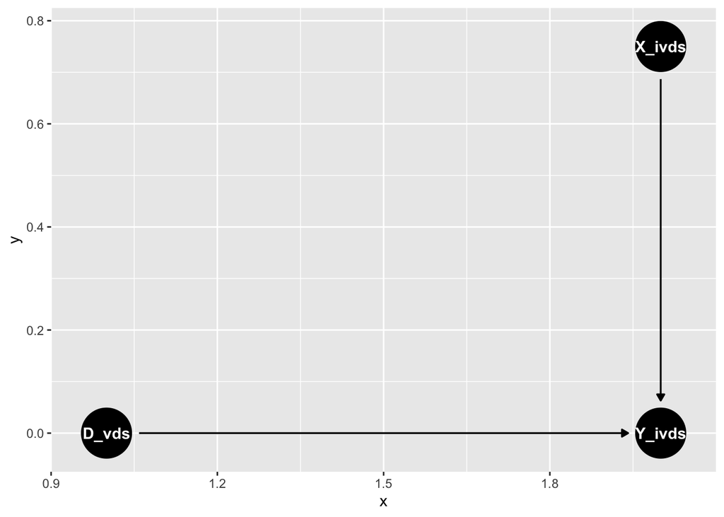

```r
mrdag <- dagitty('dag {
  "X_ivds" [pos="2,0.75"]
  "D_vds" [pos="1,0"]
  "Y_ivds" [outcome, pos="2,0"]
  X_ivds -> Y_ivds
  D_vds -> Y_ivds
}')

ggmrdag <- tidy_dagitty(mrdag)

ggdag(mrdag)
```

```r
household_data = read_dta("/Users/student/Downloads/113777-V1/AEJApp-2009-0289-data/AEJApp-2009-0289-data/household.dta")
model1 <- lm(cropincacre ~ literate + totland + bihar + caste4 + caste5 + domlow, data = household_data)
model2 <- lm(cropincacre ~ literate + totland + bihar + caste4 + caste5 + domlow +
               dist1 + dist2 + dist3 + dist4 + dist5 + dist6 + dist8 + dist9 + dist10 +
               dist11 + dist12 + dist13 + dist14 + dist16 + dist17 + dist18 + dist19 +
               dist20 + dist21 + dist22 + dist23 + dist24 + dist25, data = household_data)
model3 <- lm(cropincacre ~ literate + totland + bihar + caste4 + caste5 + domlow +
                paddy + wheat + cereal + pulse + bulb + seed + cash,
             data = household_data)
model4 <- lm(cropincacre ~ literate + totland + bihar + caste4 + caste5 + domlow +
                area + pmixdominant + tolaparea,
             data = household_data)
model4.clustered <- coeftest(model4, vcov = vcovCL, cluster = ~village, data = household_data)

model5 <- lm(cropincacre ~ literate + totland + bihar + caste4 + caste5 + domlow +
                gwdevelopment + rainfall + gwavailability + river + canal +
                noalkal + nolog + nosoil + noflood,
             data = household_data)

model5.clustered <- coeftest(model5, vcov = vcovCL, cluster = ~village, data = household_data)

model6 <- lm(cropincacre ~ literate + totland + bihar + caste4 + caste5 + domlow +
                bus3 + tele3 + ps3 + pds3 + bank3 + pps3 + ms3 + ss3 + phc3 + hosp3 +
                electric + hhelec,
             data = household_data)

model6.clustered <- coeftest(model6, vcov = vcovCL, cluster = ~village, data = household_data)

get_relevant_coefs <- function(model) {
  if (is.matrix(model)) {
    coefs <- model[c("totland", "domlow"), , drop = FALSE]
  } else {
    coefs <- coef(summary(model))[c("totland", "domlow"), ]
  }
  return(coefs)
}


mods <- list()
mods[["(1)"]] <- model1
mods[["(2)"]] <- model2
mods[["(3)"]] <- model3
mods[["(4)"]] <- model4.clustered
mods[["(5)"]] <- model5.clustered
mods[["(6)"]] <- model6.clustered
modelsummary::modelsummary(mods, keep = c("literate", "totland", "domlow"))
```

|  | (1) | (2) | (3) | (4) | (5) | (6) |
| --- | --- | --- | --- | --- | --- | --- |
| literate | 255.033 | 294.869 | 163.739 | 297.449 | 288.598 | 224.391 |
|  | (112.358) | (104.739) | (109.064) | (158.305) | (145.655) | (104.445) |
| totland | 58.521 | 52.694 | 47.837 | 55.885 | 65.590 | 50.908 |
|  | (14.352) | (14.632) | (15.289) | (19.599) | (20.552) | (15.607) |
| domlow | 566.534 | 393.355 | 387.219 | 505.566 | 668.475 | 371.266 |
|  | (111.354) | (136.740) | (109.121) | (198.638) | (254.925) | (167.651) |
| Num.Obs. | 1295 | 1295 | 1295 | 1127 | 1295 | 1122 |
| R2 | 0.126 | 0.279 | 0.202 |  |  |  |
| R2 Adj. | 0.122 | 0.263 | 0.194 |  |  |  |
| AIC | 23284.4 | 23081.6 | 23180.7 | 22575.0 | 25756.0 | 21838.1 |
| BIC | 23325.7 | 23241.8 | 23258.2 | 28190.5 | 32363.6 | 27378.3 |
| Log.Lik. | −11634.210 | −11509.825 | −11575.335 |  |  |  |
| F | 31.086 | 16.893 | 25.008 |  |  |  |
| RMSE | 1929.48 | 1752.78 | 1843.73 |  |  |  |

The OLS regression results in table 3 display a significant positive relationship between residing in a low-caste dominated village and agricultural outcome, even whilst controlling for household characteristics. The analysis also controls for potentially endogenous factors like crop choices (Column 3) and village-level public goods (Column 6).

# Section III: Role of Private Groundwater Markets

According to the author, the main determinant variable of the differences in income across different village types was access to irrigation. Table 4 shows OLS estimations of crop income, this time controlling for irrigation, credit and tenancy variables. Columns 2, 3, 4 and 5 concentrate on the effect of the interaction between being in a low caste dominated village and being a water buyer (dlbuywater) in the dataset.

```r
model1 <- lm(cropincacre ~ literate + totland + bihar + caste4 + caste5 + domlow +
             buywater + ownpump +
             dist1 + dist2 + dist3 + dist4 + dist5 + dist6 + dist8 + dist9 +
             dist10 + dist11 + dist12 + dist13 + dist14 + dist16 + dist17 +
             dist18 + dist19 + dist20 + dist21 + dist22 + dist23 + dist24 + dist25,
             data = household_data)
model1.clustered <- coeftest(model1, vcov = vcovCL, cluster = ~village, data = household_data)

model2 <- lm(cropincacre ~ literate + totland + bihar + caste4 + caste5 + domlow +
             buywater + ownpump + dlbuywater + dlownpump +
             dist1 + dist2 + dist3 + dist4 + dist5 + dist6 + dist8 + dist9 +
             dist10 + dist11 + dist12 + dist13 + dist14 + dist16 + dist17 +
             dist18 + dist19 + dist20 + dist21 + dist22 + dist23 + dist24 + dist25,
             data = household_data)
model2.clustered <- coeftest(model2, vcov = vcovCL, cluster = ~village, data = household_data)

model3 <- lm(cropincacre ~ literate + totland + bihar + caste4 + caste5 + domlow +
             buywater + ownpump + dlbuywater + dlownpump +
             paddy + wheat + cereal + pulse + bulb + seed + cash,
             data = household_data)
model3.clustered <- coeftest(model3, vcov = vcovCL, cluster = ~village, data = household_data)

model4 <- lm(cropincacre ~ literate + totland + bihar + caste4 + caste5 + domlow +
             buywater + ownpump + dlbuywater + dlownpump +
             area + pmixdominant + tolaparea,
             data = household_data)
model4.clustered <- coeftest(model4, vcov = vcovCL, cluster = ~village, data = household_data)

model5 <- lm(cropincacre ~ literate + totland + bihar + caste4 + caste5 + domlow +
             buywater + ownpump + dlbuywater + dlownpump +
             gwdevelopment + rainfall + gwavailability + river + canal +
             noalkal + nolog + nosoil + noflood,
             data = household_data)
model5.clustered <- coeftest(model5, vcov = vcovCL, cluster = ~village, data = household_data)

model6 <- lm(cropincacre ~ literate + totland + bihar + caste4 + caste5 + domlow +
             tenant + landlord + dltenant + dllandlord,
             data = household_data)
model6.clustered <- coeftest(model6, vcov = vcovCL, cluster = ~village, data = household_data)

model7 <- lm(cropincacre ~ literate + totland + bihar + caste4 + caste5 + domlow +
             bfrelsc + bfhcast + dlbfrelsc + dlbfhcast,
             data = household_data)
model7.clustered <- coeftest(model7, vcov = vcovCL, cluster = ~village, data = household_data)


exclude_vars <- c("dist1", "dist2", "dist3", "dist4", "dist5", "dist6",
                  "dist8", "dist9", "dist10", "dist11", "dist12", "dist13",
                  "dist14", "dist16", "dist17", "dist18", "dist19", "dist20",
                  "dist21", "dist22", "dist23", "dist24", "dist25", "caste1", "caste2", "caste3", "caste5", "caste4", "totland", "bihar", "literate")
all_vars <- c(names(coef(model1)), c("landlord","tenant",  "dllandlord", "dltenant","bfhcast","bfrelsc",  "dlbfhcast", "dlbfrelsc"))
keep_vars <- setdiff(all_vars, exclude_vars) # variables we won't display

table4 = list()
table4[["(1)"]] <- model1.clustered
table4[["(2)"]] <- model2.clustered
table4[["(3)"]] <- model3.clustered
table4[["(4)"]] <- model4.clustered
table4[["(5)"]] <- model5.clustered
table4[["(6)"]] <- model6.clustered
table4[["(7)"]] <- model7.clustered
modelsummary::modelsummary(table4, keep = keep_vars)
```

|  | (1) | (2) | (3) | (4) | (5) | (6) | (7) |
| --- | --- | --- | --- | --- | --- | --- | --- |
| (Intercept) | 507.570 | 739.568 | 716.940 | 1080.140 | 269.159 | 1055.383 | 1135.188 |
|  | (142.095) | (170.227) | (252.922) | (291.833) | (524.185) | (226.049) | (225.347) |
| domlow | 346.223 | −87.981 | 19.018 | −162.090 | 48.087 | 654.408 | 740.739 |
|  | (196.165) | (165.930) | (137.124) | (186.295) | (175.025) | (245.910) | (259.690) |
| buywater | 318.148 | −143.015 | 43.426 | −233.916 | −225.707 |  |  |
|  | (127.949) | (174.861) | (192.994) | (171.668) | (172.633) |  |  |
| ownpump | 1119.628 | 865.734 | 755.760 | 841.025 | 703.337 |  |  |
|  | (259.973) | (474.415) | (496.963) | (532.751) | (524.095) |  |  |
| dlbuywater |  | 850.936 | 602.136 | 980.677 | 901.781 |  |  |
|  |  | (274.975) | (254.380) | (333.931) | (273.745) |  |  |
| dlownpump |  | 388.522 | 365.342 | 773.228 | 654.818 |  |  |
|  |  | (500.403) | (593.921) | (682.007) | (600.064) |  |  |
| tenant |  |  |  |  |  | 79.310 |  |
|  |  |  |  |  |  | (106.147) |  |
| landlord |  |  |  |  |  | −324.249 |  |
|  |  |  |  |  |  | (173.034) |  |
| dltenant |  |  |  |  |  | −420.674 |  |
|  |  |  |  |  |  | (288.995) |  |
| dllandlord |  |  |  |  |  | 189.559 |  |
|  |  |  |  |  |  | (323.194) |  |
| bfrelsc |  |  |  |  |  |  | −234.824 |
|  |  |  |  |  |  |  | (124.961) |
| bfhcast |  |  |  |  |  |  | −28.583 |
|  |  |  |  |  |  |  | (160.973) |
| dlbfrelsc |  |  |  |  |  |  | −482.738 |
|  |  |  |  |  |  |  | (292.185) |
| dlbfhcast |  |  |  |  |  |  | −542.512 |
|  |  |  |  |  |  |  | (318.740) |
| Num.Obs. | 1295 | 1295 | 1295 | 1127 | 1295 | 1295 | 1295 |
| AIC | 25501.0 | 25479.9 | 25670.1 | 22500.9 | 25689.1 | 25831.4 | 25816.9 |
| BIC | 32026.0 | 31994.6 | 32267.4 | 28096.3 | 32276.1 | 32464.9 | 32450.4 |

As the researcher discovered, an examination of Table 4 reveals that once we control for the interaction between being a water buyer and residing in a low-caste village, the effect alone of being in a low-caste village is no longer significant. In fact, the true determinant appears to be access to irrigation across different types of villages. However, there is no significant effect for the interaction between owning a tubewell and residing in a low cast village on the crop income.

However, we could still have concerns about endogeneity, because characteristics of water buyers across type of villages (low caste vs high caste dominated) may still differ systematically. To solve this problem, the researcher adopted an instrumental variable approach to isolate the true causal impact of being a water buyer from other confounding influences. She used two instruments. The first one is **access to natural water sources** as it is hypothesized that greater natural water availability reduces the necessity for households to buy water from private sources. The second one is **total area of the village** as larger village areas are thought to have increased the transaction costs associated with water trade and thereby reducing the propensity to buy water. The choice of these instruments is based on the idea that they influence the need and frequency of engaging in private groundwater market (relevance), but are not directly related to the caste dominance of the village (exogeneity).

The first stage of the 2SLS regression model is given by **equation 3**:

$$(3)WB_{ivds} = \alpha_0 + \alpha_1 X_{ivds} + \alpha_2 D_{vds} +
\alpha_3 Z_{vds} + \delta_s + \phi_s + \xi_{ivds}$$

Where: $WB_{ivds}$ is the indicator variable for whether household $i$ in village $v$, district $d$, and state $s$ is a water buyer. $X_{ivds}$ includes control variables such as household characteristics and other exogenous factors. $D_{vds}$ is a dummy variable for whether the village is dominated by a lower caste. $Z_{vds}$ is a vector of instrumental variables, specifically including natural water sources and total area of the village, which are used to instrument $WB_{ivds}$. $\delta_s$ and $\phi_s$ represent district and state fixed effects, respectively. $\xi_{ivds}$ is the error term.

The second stage of the 2SLS regression model uses the predicted value of $WB_{ivds}$ from the first stage to estimate the impact on crop income per acre. This approach allows the researcher to isolate the causal impact of being a water buyer from other confounding factors.

After obtaining the predicted values ($\widehat{WB}_{ivds}$) from equation (3), the researcher uses them in two first-stage equations to identify the endogenous regressors.

**Equation (4)** : This equation estimates the determinants of water buying status ($WB_{ivds}$) while controlling for caste dominance and other characteristics:

$$(4) WB_{ivds} = \pi_0 + \pi_1 X_{ivds} + \pi_2 D_{vds} + \pi_3
\widehat{WB}_{ivds} + \pi_4 D_{vds} \times \widehat{WB}_{ivds} +
\tau_{ds} + \rho_s + \eta_{ivds}$$

where: $\pi_0$, $\pi_1$, $\pi_2$, $\pi_3$, and $\pi_4$ are coefficients to be estimated. $\tau_{ds}$ and $\rho_s$ represent district and state fixed effects, respectively. $\eta_{ivds}$ is the error term.

**Equation (5)**: This equation explores the determinants of the interaction between caste dominance and water buyer status:

$$(5) D \times WB_{ivds} = \lambda_0 + \lambda_1 X_{ivds} + \lambda_2
D_{vds} + \lambda_3 \widehat{WB}_{ivds} + \lambda_4 D_{vds} \times
\widehat{WB}_{ivds} + \psi_{ds} + \omega_s + \nu_{ivds}$$

where: $\lambda_0$, $\lambda_1$, $\lambda_2$, $\lambda_3$, and $\lambda_4$ are coefficients to be estimated. $\psi_{ds}$ and $\omega_s$ represent district and state fixed effects, respectively. $\nu_{ivds}$ is the error term.

The **second stage equation** is given by **equation 2**:

$$(2) Y_{ivds} = \gamma_0 + \gamma_1 X_{ivds} + \gamma_2 D_{vds} +
\gamma_3 \widehat{WB}_{ivds} + \gamma_4 D_{vds} \times
\widehat{WB}_{ivds} + \delta_{ds} + \phi_s + \xi_{ivds}$$
where: $Y_{ivds}$ is crop income per acre. $X_{ivds}$ includes control variables such as household characteristics and other exogenous factors. $D_{vds}$ is a dummy variable for whether the village is dominated by a lower caste. $\widehat{WB}_{ivds}$ is the predicted value of whether a household $i$ in village $v$, district $d$, and state $s$ is a water buyer, from the first stage equation. $D_{vds} \times \widehat{WB}_{ivds}$ is the interaction term between caste dominance and water buying status. $\delta_{ds}$ and $\phi_s$ represent district and state fixed effects, respectively. $\xi_{ivds}$ is the error term.

```r
model_ols <- lm(buywater ~ totland + bihar + caste4 + caste5 + domlow + area + naturalwater + dist1 + dist2 + dist3 + dist4 + dist5 + dist7 + dist8 + dist9 + dist11 + dist13 + dist14 + dist15 + dist16 + dist17 + dist20 + dist22 + dist24 + dist25, data = household_data, na.action = na.exclude)
model_ols.clustered <- coeftest(model_ols, vcovCL(model_ols, cluster = ~village))

# Store the predicted values of buywater
household_data$bw_hat <- predict(model_ols, type = "response")
household_data$dlbw_hat <- household_data$domlow * household_data$bw_hat

model_ols2 <- lm(buywater ~ totland + bihar + caste4 + caste5 + domlow +  bw_hat + dlbw_hat + dist1 + dist2 + dist3 + dist4 + dist5 + dist7 + dist8 + dist9 + dist11 + dist13 + dist14 + dist15 + dist16 + dist17 + dist20 + dist22 + dist24 + dist25, data = household_data, na.action = na.exclude)
model_ols2.clustered <- coeftest(model_ols2, vcov = vcovCL, cluster = ~village, data = household_data)

model_ols3 <- lm(dlbuywater ~ totland + bihar + caste4 + caste5 + domlow +  bw_hat + dlbw_hat + dist1 + dist2 + dist3 + dist4 + dist5 + dist7 + dist8 + dist9 + dist11 + dist13 + dist14 + dist15 + dist16 + dist17 + dist20 + dist22 + dist24 + dist25, data = household_data, na.action = na.exclude)
model_ols3.clustered <- coeftest(model_ols3, vcov = vcovCL, cluster = ~village, data = household_data)

household_data$bw_hat <- predict(model_ols2, type = "response")
household_data$dlbw_hat <- predict(model_ols3, type = "response")


iv_model <- ivreg(cropincacre ~ buywater + dlbuywater + totland + bihar + caste4 + caste5 + domlow + dist1 + dist2 + dist3 + dist4 + dist5 + dist18 + dist21 + dist7 + dist8 + dist9 + dist10 + dist11 + dist13 + dist14 + dist15 + dist16 + dist17 + dist20 + dist22 + dist24 + dist25 | bw_hat + dlbw_hat + totland + bihar + caste4 + caste5 + domlow + dist1 + dist2 + dist3 + dist4 + dist5 + dist18 + dist21 + dist7 + dist8 + dist9 + dist10 + dist11 + dist13 + dist14 + dist15 + dist16 + dist17 + dist20 + dist22 + dist24 + dist25, data = household_data)
clustered_vcov <- vcovCL(iv_model, cluster = ~village, data = household_data)
iv_model.clustered <- coeftest(iv_model, clustered_vcov)

exclude_vars <- c("dist1", "dist2", "dist3", "dist4", "dist5", "dist6", "dist7",
                  "dist8", "dist9", "dist10", "dist11", "dist12", "dist13",
                  "dist14","dist14", "dist16", "dist17", "dist18", "dist19", "dist20",
                  "dist21", "dist22", "dist23", "dist24", "dist25", "caste1", "caste2", "caste3", "caste5", "caste4", "totland", "bihar", "literate")

all_vars <- c(names(coef(iv_model)), c("naturalwater", "area", "bw_hat", "dlbw_hat"))
# Remove the variables you want to exclude from all_vars
keep_vars <- setdiff(all_vars, exclude_vars)

table5 = list()
table5[["(1)"]] <- model_ols.clustered
table5[["(2)"]] <- model_ols2.clustered
table5[["(3)"]] <- model_ols3.clustered
table5[["(4)"]] <- iv_model.clustered
modelsummary::modelsummary(table5, keep = keep_vars)
```

|  | (1) | (2) | (3) | (4) |
| --- | --- | --- | --- | --- |
| (Intercept) | 0.837 | −0.012 | 0.061 | 588.012 |
|  | (0.060) | (0.109) | (0.069) | (520.806) |
| domlow | 0.070 | 0.161 | 0.113 | −1522.848 |
|  | (0.048) | (0.113) | (0.091) | (819.275) |
| area | 0.000 |  |  |  |
|  | (0.000) |  |  |  |
| naturalwater | −0.186 |  |  |  |
|  | (0.040) |  |  |  |
| bw_hat |  | 1.087 | −0.036 |  |
|  |  | (0.117) | (0.077) |  |
| dlbw_hat |  | −0.289 | 0.812 |  |
|  |  | (0.175) | (0.132) |  |
| buywater |  |  |  | 202.087 |
|  |  |  |  | (937.438) |
| dlbuywater |  |  |  | 3519.509 |
|  |  |  |  | (1422.635) |
| Num.Obs. | 1127 | 1127 | 1127 | 1127 |
| AIC | 3611.0 | 3607.5 | 2955.5 | 22687.2 |
| BIC | 9151.1 | 9147.6 | 8495.6 | 28212.3 |

The fourth column of table 5 represents the results from the second-stage of the 2SLS estimations of crop income with the water buyer variable included. The significant positive coefficient indicates that the interaction of being a water buyer in a low-caste village significantly increases agricultural income by approximately $3,519.5, significant at the 5% level. Confirming the OLS estimation of table 4, this result supports the hypothesis that low-caste water buyers in low-caste dominated villages benefit disproportionately in terms of agricultural income, likely due to better access to resources or favorable conditions that are not as available to non-water buyers or those in high-caste dominated villages.

In our analysis, we utilized a Probit model because we deemed it relevant for the nature of our dependent variable, buywater, which is binary, and predictor variables such as area, which is continuous. This approach complements other tests in the paper in regards to the impact of our instrumental variables. As we can see both instruments have a significant negative effect on being a water buyer. In addition, the blue ROC Curve (with both IV) is the one closer to upper left corner which could reinforce the choice of these instruments. The accuracy graph shows that the model with both IV is overall more accurate and has a peak around the 0.5 cutoff.

```r
household_data <- read_dta("/Users/student/Downloads/113777-V1/AEJApp-2009-0289-data/AEJApp-2009-0289-data/household.dta")

clean_data <- household_data[!is.na(household_data$buywater), ]
clean_data <- clean_data[complete.cases(clean_data), ]
clean_data$buywater <- factor(clean_data$buywater, levels = c(0, 1), labels = c("No", "Yes"))

# Create three separate probit models to compare them
f_full <- "buywater ~ totland + bihar + caste4 + caste5 + domlow + area + naturalwater + dist1 + dist2 + dist3 + dist4 + dist5 + dist7 + dist8 + dist9 + dist11 + dist13 + dist14 + dist16 + dist17 + dist20 + dist22 + dist24 + dist25"
f_area <- "buywater ~ totland + bihar + caste4 + caste5 + domlow + area + dist1 + dist2 + dist3 + dist4 + dist5 + dist7 + dist8 + dist9 + dist11 + dist13 + dist14 + dist16 + dist17 + dist20 + dist22 + dist24 + dist25"
f_naturalwater <- "buywater ~ totland + bihar + caste4 + caste5 + domlow + naturalwater + dist1 + dist2 + dist3 + dist4 + dist5 + dist7 + dist8 + dist9 + dist11 + dist13 + dist14 + dist16 + dist17 + dist20 + dist22 + dist24 + dist25"

glms <- list()
glms$probit_area <- glm(formula = f_area, data = clean_data, family = binomial(link = "probit"))
glms$probit_naturalwater <- glm(formula = f_naturalwater, data = clean_data, family = binomial(link = "probit"))

glms_full <- list()
glms_full$probit_full <- glm(formula = f_full, data = clean_data, family = binomial(link = "probit"))
glms_full$probitMean <- mfx::probitmfx(formula = f_full, data = clean_data, atmean = TRUE)
glms_full$probitAvg <- mfx::probitmfx(formula = f_full, data = clean_data, atmean = FALSE)
ht <- huxtable::huxreg(
  "Probit Full Model" = glms_full$probit_full,
  "Probit Mean" = glms_full$probitMean,
  "Probit Average" = glms_full$probitMean,
  coefs = c("naturalwater", "area"),
  number_format = "%.4f"
)

ht <- huxtable::set_caption(ht, "Probit Models Summary")
ht <- huxtable::set_all_borders(ht, 1)
ht <- huxtable::set_all_padding(ht, 2)
ht
```

Probit Models Summary

|  | Probit Full Model | Probit Mean | Probit Average |
| --- | --- | --- | --- |
| naturalwater | -0.4297 *** | -0.1698 *** | -0.1698 *** |
|  | (0.1130) | (0.0440) | (0.0440) |
| area | -0.0006 *** | -0.0002 *** | -0.0002 *** |
|  | (0.0001) | (0.0000) | (0.0000) |
| N | 959 | 0 | 0 |
| logLik | -559.8957 | -559.8957 | -559.8957 |
| AIC | 1169.7914 | 1169.7914 | 1169.7914 |
| *** p < 0.001; ** p < 0.01; * p < 0.05. |  |  |  |

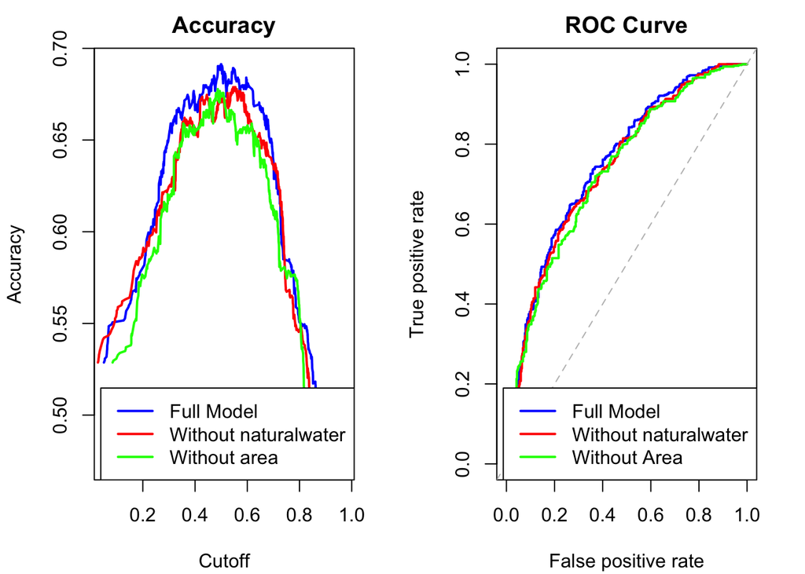

```r
pred_full <- prediction(fitted(glms_full$probit_full), clean_data$buywater)
pred_area <- prediction(fitted(glms$probit_area), clean_data$buywater)
pred_naturalwater <- prediction(fitted(glms$probit_naturalwater), clean_data$buywater)

perf_full_acc <- performance(pred_full, "acc")
perf_area_acc <- performance(pred_area, "acc")
perf_naturalwater_acc <- performance(pred_naturalwater, "acc")

perf_full_roc <- performance(pred_full, "tpr", "fpr")
perf_area_roc <- performance(pred_area, "tpr", "fpr")
perf_naturalwater_roc <- performance(pred_naturalwater, "tpr", "fpr")

par(mfrow = c(1, 2), mar = c(4, 4, 2, 2) + 0.1)
# Accuracy plot
plot(perf_full_acc, col = "blue", lwd = 2, main = "Accuracy")
plot(perf_area_acc, add = TRUE, col = "red", lwd = 2)
plot(perf_naturalwater_acc, add = TRUE, col = "green", lwd = 2)
legend("bottomright", legend = c("Full Model", "Without naturalwater", "Without area"), col = c("blue", "red", "green"), lty = 1, lwd = 2)

# ROC plot
plot(perf_full_roc, col = "blue", lwd = 2, main = "ROC Curve")
plot(perf_area_roc, add = TRUE, col = "red", lwd = 2)
plot(perf_naturalwater_roc, add = TRUE, col = "green", lwd = 2)
abline(0, 1, lty = 2, col = "gray")
legend("bottomright", legend = c("Full Model", "Without naturalwater", "Without Area"), col = c("blue", "red", "green"), lty = 1, lwd = 2)
```

Here, Table 6 is used to analyse the supply and demand in village water markets, taking into consideration caste dynamics. It used data on total cultivated and owned land, as well as the number of water buyers, sellers, and pump owners. The table is divided into two sections - the first examines all castes collectively, while the second focuses specifically on lower castes.

```r
table6_data <- read_dta("/Users/student/Downloads/113777-V1/AEJApp-2009-0289-data/AEJApp-2009-0289-data/table6.dta")

# Function to perform t-tests and extract means, differences, and standard errors
analyze_data <- function(var, name) {
    t_test <- t.test(reformulate("domhigh", response = var), data = table6_data)
    high_mean <- t_test$estimate['mean in group 1']
    low_mean <- t_test$estimate['mean in group 0']
    mean_diff <- high_mean - low_mean
    std_error <- t_test$stderr
    p_value <- t_test$p.value

    significance <- if (p_value < 0.001) {
        "***"
    } else if (p_value < 0.01) {
        "**"
    } else if (p_value < 0.05) {
        "*"
    } else {
        ""
    }

    data.frame(
        Variable = name,
        `High-caste Mean` = high_mean,
        `Low-caste Mean` = low_mean,
        `Difference of Means` = sprintf("%.2f (%.2f)%s", mean_diff, std_error, significance)
    )
}

first_panel_vars <- c(
    popallcrop = "Cultivated Acres",
    popallland = "Acres Owned",
    popall = "Population",
    buypop = "Buyers per Capita",
    abuycrop = "Buyers/Land Cultivated",
    abuyland = "Buyers/Land Owned",
    sellpop = "Sellers per Capita",
    asellcrop = "Sellers/Land Cultivated",
    asellland = "Sellers/Land Owned",
    pumppop = "Pumps per Capita",
    aowncrop = "Pumps/Land Cultivated",
    aownland = "Pumps/Land Owned"
)

second_panel_vars <- c(
    poplowcrop = "Cultivated Acres",
    poplowland = "Acres Owned",
    poplow = "Population",
    buywater = "Buyers per Capita",
    lbuycrop = "Buyers/Land Cultivated",
    lbuyland = "Buyers/Land Owned",
    sellwater = "Sellers per Capita",
    lsellcrop = "Sellers/Land Cultivated",
    lsellland = "Sellers/Land Owned",
    ownpump = "Pumps per Capita",
    lowncrop = "Pumps/Land Cultivated",
    lownland = "Pumps/Land Owned"
)

first_panel_results <- mapply(analyze_data, names(first_panel_vars), first_panel_vars, SIMPLIFY = FALSE)
first_panel_df <- do.call(rbind, first_panel_results)
second_panel_results <- mapply(analyze_data, names(second_panel_vars), second_panel_vars, SIMPLIFY = FALSE)
second_panel_df <- do.call(rbind, second_panel_results)

options(scipen = 999)


knitr::kable(first_panel_df, caption = "Markets at the Village: All Castes (First Panel)")
```

Markets at the Village: All Castes (First Panel)

|  | Variable | High.caste.Mean | Low.caste.Mean | Difference.of.Means |
| --- | --- | --- | --- | --- |
| popallcrop | Cultivated Acres | 883.8424731 | 915.1857333 | -31.34 (171.94) |
| popallland | Acres Owned | 468.5788185 | 436.3860002 | 32.19 (89.77) |
| popall | Population | 208.1458333 | 236.8809524 | -28.74 (28.37) |
| buypop | Buyers per Capita | 0.7039035 | 0.7521109 | -0.05 (0.05) |
| abuycrop | Buyers/Land Cultivated | 0.2146490 | 0.2179929 | -0.00 (0.04) |
| abuyland | Buyers/Land Owned | 0.6211784 | 0.4558691 | 0.17 (0.28) |
| sellpop | Sellers per Capita | 0.0966614 | 0.1164140 | -0.02 (0.02) |
| asellcrop | Sellers/Land Cultivated | 0.0218792 | 0.0314408 | -0.01 (0.01) |
| asellland | Sellers/Land Owned | 0.0475800 | 0.0627388 | -0.02 (0.01) |
| pumppop | Pumps per Capita | 0.1458877 | 0.1804473 | -0.03 (0.03) |
| aowncrop | Pumps/Land Cultivated | 0.0427489 | 0.0578815 | -0.02 (0.01) |
| aownland | Pumps/Land Owned | 0.0868093 | 0.1135218 | -0.03 (0.02) |

```r
knitr::kable(second_panel_df, caption = "Markets at the Village: Low Castes (Second Panel)")
```

Markets at the Village: Low Castes (Second Panel)

|  | Variable | High.caste.Mean | Low.caste.Mean | Difference.of.Means |
| --- | --- | --- | --- | --- |
| poplowcrop | Cultivated Acres | 433.4543559 | 886.0225372 | -452.57 (146.54)** |
| poplowland | Acres Owned | 172.3036849 | 415.8249191 | -243.52 (74.07)** |
| poplow | Population | 140.0208333 | 230.7619048 | -90.74 (24.98)*** |
| buywater | Buyers per Capita | 0.7324905 | 0.7506795 | -0.02 (0.06) |
| lbuycrop | Buyers/Land Cultivated | 0.4156161 | 0.2200358 | 0.20 (0.08)* |
| lbuyland | Buyers/Land Owned | 1.4533843 | 0.4656061 | 0.99 (0.35)** |
| sellwater | Sellers per Capita | 0.0623429 | 0.1153384 | -0.05 (0.02)* |
| lsellcrop | Sellers/Land Cultivated | 0.0162776 | 0.0310495 | -0.01 (0.01) |
| lsellland | Sellers/Land Owned | 0.0429604 | 0.0622660 | -0.02 (0.02) |
| ownpump | Pumps per Capita | 0.0904621 | 0.2289804 | -0.14 (0.03)*** |
| lowncrop | Pumps/Land Cultivated | 0.0238355 | 0.0559556 | -0.03 (0.01)** |
| lownland | Pumps/Land Owned | 0.0649497 | 0.1121453 | -0.05 (0.02)* |

The comparison of the two panels in Table 6 helps illustrate how caste dynamics affect water trading in the villages studied. The first panel, which considers all castes collectively, shows no significant differences in water market activity between villages dominated by different castes. This suggests that caste isn’t a factor influencing water trade at a macro level.

However, the second panel, which focuses on lower castes, reveals significant disparities. Lower-caste dominated villages display a higher number of water sellers and pump owners, but a lower number of buyers compared to upper-caste dominated villages. This implies that water prices for lower castes are likely lower in villages where they predominate, indicating a potential breakdown in water trade across caste lines.

According to the original study only a small number of individuals in each village own water pipes, and these owners typically engage in verbal agreements with potential buyers. These agreements often involve a fixed cost for buyers, who must invest in infrastructure to channel water to their fields. Once this investment is made, buyers encounter a typical holdup problem: having committed their resources, they find themselves at the mercy of the sellers. The informal nature of these agreements provides limited means of recourse, making it challenging for buyers to assert their rights or seek redress. This problem is further compounded for lower caste buyers when the sellers are from higher castes. Due to the social dynamics, lower caste individuals have even fewer means to challenge or negotiate with upper caste sellers, exacerbating their vulnerability in these transactions. The backward induction graph below illustrate and show how the holdup problem could discourage investment among low cast household in high caste dominated villages.

```r
graph <- grViz("
digraph decision_tree {

  graph [layout = dot]
  node [shape = box, style = filled, color = black, fillcolor = lightgrey]
  edge [color = black]


  farmer [label = 'Buyer', shape = ellipse, fillcolor = '#BFD7B5']
  invest [label = 'Seller', shape = box, fillcolor = lightgrey]
  not_invest [label = 'B_Surplus:0, S_Surplus:0', shape = ellipse, fillcolor = '#F1B5CB']
  renegotiate [label = 'Buyer', shape = ellipse, fillcolor = '#BFD7B5']
  not_renegotiate [label = 'Buyer', shape = ellipse, fillcolor = '#BFD7B5']
  stay [label = 'B_Surplus:20, S_Surplus:25', shape = ellipse, fillcolor = '#FFFFD2']
  move [label = 'B_Surplus:-20, S_Surplus:0', shape = ellipse, fillcolor = '#FFFFD2']
  stay_2 [label = 'B_Surplus:-5, S_Surplus:50', shape = ellipse, fillcolor = '#FFFFD2']
  move_2 [label = 'B_Surplus:-20, S_Surplus:0', shape = ellipse, fillcolor = '#FFFFD2']

  farmer -> invest [color=red, label='invest']
  farmer -> not_invest [color=green, label='no invest']
  invest -> renegotiate [color=red, label='no renegotiation']
  invest -> not_renegotiate [color=green, label='renegotiate']
  renegotiate -> stay [color=green, label='stay']
  renegotiate -> move [color=red, label='move']
  not_renegotiate -> stay_2 [color=green, label='stay']
  not_renegotiate -> move_2 [color=red, label='move']
}
")
graph
```

[interactive chart not shown]

To conclude, agricultural yields are systematically higher for low-caste households residing in villages dominated by lower castes compared to those dominated by upper castes. The access to groundwater irrigation is likely to be the main determinant because private groundwater markets seem to be more efficient where the caste composition is more homogeneous. As the original study suggests, the holdup problem exacerbated by the caste system discourages investment among low-caste households in villages dominated by higher castes. Informal water agreements often leave lower-caste buyers vulnerable, particularly when dealing with upper-caste sellers, due to social hierarchies that limit their ability to negotiate or assert their rights. While the original paper discusses the irrelevance of other alternatives explanations (groundwater quality, tenancy and credit relations, land quality and land size), it highlights how deeply embedded social structures influence economic outcomes. providing insights into the role of social dynamics in shaping market efficiency in this specific context. It provides valuable insights into the role of social dynamics in shaping market efficiency within this specific context.